# Biostat 203B Homework 4

Due Mar 18 @ 11:59PM

Yiyao Hu

Load database libraries and the tidyverse frontend:

```r
suppressPackageStartupMessages(library(tidyverse))
suppressPackageStartupMessages(library(lubridate))
suppressPackageStartupMessages(library(miceRanger))
```

## Q1. Missing data

Through the Shiny app developed in HW3, we observe abundant missing values in the MIMIC-IV ICU cohort we created. In this question, we use multiple imputation to obtain a data set without missing values.

### 0. Read following tutorials on the R package miceRanger for imputation: https://github.com/farrellday/miceRanger, https://cran.r-project.org/web/packages/miceRanger/vignettes/miceAlgorithm.html.

```
A more thorough book treatment of the practical imputation strategies is the book [*_Flexible Imputation of Missing Data_*](https://stefvanbuuren.name/fimd/) by Stef van Buuren.
```

### 1. Explain the jargon MCAR, MAR, and MNAR.

**Solutions:**

Reference: https://stats.oarc.ucla.edu/stata/seminars/mi_in_stata_pt1_new

“Missing completely at random (MCAR) A variable is missing completely at random, if neither the variables in the dataset nor the unobserved value of the variable itself predict whether a value will be missing. Missing completely at random is a fairly strong assumption and may be relatively rare. One relatively common situation in which data are missing completely at random occurs when a subset of cases is randomly selected to undergo additional measurement, this is sometimes referred to as “planned missing.” For example, in some health surveys, some subjects are randomly selected to undergo more extensive physical examination; therefore only a subset of participants will have complete information for these variables. Missing completely at random also allow for missing on one variable to be related to missing on another, e.g. var1 is missing whenever var2 is missing. For example, a husband and wife are both missing information on height.”

“Missing at random (MAR) A variable is said to be missing at random if other variables (but not the variable itself) in the dataset can be used to predict missingness on a given variable. For example, in surveys, men may be more likely to decline to answer some questions than women (i.e., gender predicts missingness on another variable). MAR is a less restrictive assumption than MCAR. Under this assumption the probability of missingness does not depend on the true values after controlling for the observed variables. MAR is also related to ignorability. The missing data mechanism is said be ignorable if it is missing at random and the probability of a missingness does not depend on the missing information itself. The assumption of ignorability is needed for optimal estimation of missing information and is a required assumption for both of the missing data techniques we will discuss.”

“Missing not at random (MNAR) Finally, data are said to be missing not at random if the value of the unobserved variable itself predicts missingness. A classic example of this is income. Individuals with very high incomes are more likely to decline to answer questions about their income than individuals with more moderate incomes.”

“An understanding of the missing data mechanism(s) present in your data is important because different types of missing data require different treatments. When data are missing completely at random, analyzing only the complete cases will not result in biased parameter estimates (e.g., regression coefficients). However, the sample size for an analysis can be substantially reduced, leading to larger standard errors. In contrast, analyzing only complete cases for data that are either missing at random, or missing not at random can lead to biased parameter estimates. Multiple imputation and other modern methods such as direct maximum likelihood generally assumes that the data are at least MAR, meaning that this procedure can also be used on data that are missing completely at random. Statistical models have also been developed for modeling the MNAR processes; however, these model are beyond the scope of this seminar.”

### 2. Explain in a couple of sentences how the Multiple Imputation by Chained Equations (MICE) work.

**Solution:**

Reference:

```
       1) https://stats.oarc.ucla.edu/stata/seminars/mi_in_stata_pt1_new

       2) https://cran.r-project.org/web/packages/miceRanger/vignettes/miceAlgorithm.html

       3）https://github.com/farrellday/miceRanger

       4）https://www.rdocumentation.org/packages/miceRanger/versions/1.3.4/topics/miceRanger
```

Overall Principle:

“miceRanger can make use of a procedure called predictive mean matching (PMM) to select which values are imputed. PMM involves selecting a datapoint from the original, nonmissing data which has a predicted value close to the predicted value of the missing sample. The closest N (meanMatchCandidates parameter in miceRanger()) values are chosen as candidates, from which a value is chosen at random.”

This method is very useful if you have a variable which needs imputing which has any of the following characteristics: Multimodal, Integer, Skewed

Common Use Cases of MICE 1) Data Leakage 2) Integer 3) Skewed

### 3. Perform a data quality check of the ICU stays data. Discard variables with substantial missingness, say >5000 `NA`s. Replace apparent data entry errors by `NA`s.

Step 1:

Import icu_cohort data

```r
icu_cohort <- readRDS("~/Biostat-203b-winter-2022/HW4/icu_cohort.rds")
```

Step 2:

Perform a data quality check of the ICU stays data and drop variables with substantial missing data.

The following variables have substantial missingness (> 5000 NAS):

```r
na_count <-sapply(icu_cohort, function(x) sum(is.na(x)))
na_count <- data.frame(na_count)
na_count
```

```
##                      na_count
## subject_id                  0
## hadm_id                     0
## stay_id                     0
## first_careunit              0
## last_careunit               0
## intime                      0
## outtime                     0
## los                         0
## admittime                   0
## dischtime                   0
## deathtime               46834
## admission_type              0
## admission_location          0
## discharge_location        506
## insurance                   0
## language                    0
## marital_status           4561
## ethnicity                   0
## edregtime               19162
## edouttime               19162
## hospital_expire_flag        0
## Year                        0
## Month                       0
## monthday                    0
## weekday                     0
## hour                        0
## gender                      0
## anchor_age                  0
## anchor_year                 0
## anchor_year_group           0
## dod                     45191
## labitemid                   0
## labvaluenum                 0
## vitalitemid                 0
## vitalvaluenum               0
## length                      0
## thirty_day_mort             0
```

```r
# get names of variables with substantial missingness (>5000 NAs)
Miss_var <-row.names(na_count)[apply(na_count, 2, function(i) which(i > 5000))]
Miss_var
```

```
## [1] "deathtime" "edregtime" "edouttime" "dod"
```

```r
# Drop these variables from the table
icu_cohort <- subset(icu_cohort, select = -c(deathtime, edregtime,
                                             edouttime, dod))
```

Step 3:

The summary shows the following four variables might have error inpput:

1. los 2) labvaluenum 3) vitalvaluenum 4) length

```r
# Check basic info of each of the 33 variables
dim(icu_cohort)
```

```
## [1] 53087    33
```

```r
summary(icu_cohort)
```

```
##    subject_id          hadm_id            stay_id         first_careunit
##  Min.   :10000032   Min.   :20000094   Min.   :30000153   Length:53087
##  1st Qu.:12483096   1st Qu.:22483297   1st Qu.:31920206   Class :character
##  Median :14991624   Median :24955456   Median :34220995   Mode  :character
##  Mean   :14990165   Mean   :24976147   Mean   :34481227
##  3rd Qu.:17497981   3rd Qu.:27474726   3rd Qu.:36928100
##  Max.   :19999987   Max.   :29999828   Max.   :39999810
##  last_careunit          intime                       outtime
##  Length:53087       Min.   :2110-01-11 10:16:06   Min.   :2110-01-12 17:17:47
##  Class :character   1st Qu.:2132-12-23 14:09:10   1st Qu.:2132-12-27 16:57:54
##  Mode  :character   Median :2152-11-15 00:46:00   Median :2152-11-20 21:06:57
##                     Mean   :2152-12-28 17:51:18   Mean   :2153-01-01 02:00:28
##                     3rd Qu.:2173-01-01 06:24:00   3rd Qu.:2173-01-05 19:54:58
##                     Max.   :2211-05-01 06:59:19   Max.   :2211-05-10 22:51:06
##       los              admittime
##  Min.   :  0.00125   Min.   :2110-01-11 10:14:00
##  1st Qu.:  1.08310   1st Qu.:2132-12-21 04:27:30
##  Median :  1.88344   Median :2152-11-14 02:41:00
##  Mean   :  3.33969   Mean   :2152-12-27 06:05:06
##  3rd Qu.:  3.54380   3rd Qu.:2172-12-30 19:16:30
##  Max.   :103.49900   Max.   :2211-05-01 06:57:00
##    dischtime                   admission_type     admission_location
##  Min.   :2110-01-15 17:31:00   Length:53087       Length:53087
##  1st Qu.:2132-12-30 15:00:30   Class :character   Class :character
##  Median :2152-11-25 15:27:00   Mode  :character   Mode  :character
##  Mean   :2153-01-05 16:59:08
##  3rd Qu.:2173-01-09 16:35:30
##  Max.   :2211-05-12 17:54:00
##  discharge_location  insurance           language         marital_status
##  Length:53087       Length:53087       Length:53087       Length:53087
##  Class :character   Class :character   Class :character   Class :character
##  Mode  :character   Mode  :character   Mode  :character   Mode  :character
##
##
##
##   ethnicity         hospital_expire_flag      Year          Month
##  Length:53087       Min.   :0.0000       Min.   :2110   Min.   : 1.000
##  Class :character   1st Qu.:0.0000       1st Qu.:2132   1st Qu.: 4.000
##  Mode  :character   Median :0.0000       Median :2152   Median : 7.000
##                     Mean   :0.1179       Mean   :2152   Mean   : 6.528
```

[output cut: 15 more lines]

```
##  Max.   :91.00   Max.   :2207                      Max.   :51301
##   labvaluenum      vitalitemid     vitalvaluenum         length
##  Min.   :  0.10   Min.   :220045   Min.   :      0   Min.   :  0.000
##  1st Qu.: 24.00   1st Qu.:220045   1st Qu.:     76   1st Qu.:  0.000
##  Median : 30.20   Median :220045   Median :     91   Median :  0.000
##  Mean   : 34.18   Mean   :220601   Mean   :    153   Mean   :  1.186
##  3rd Qu.: 39.40   3rd Qu.:220179   3rd Qu.:    101   3rd Qu.:  0.000
##  Max.   :449.00   Max.   :223761   Max.   :3333330   Max.   :378.000
##  thirty_day_mort
##  Min.   :0.0000
##  1st Qu.:0.0000
##  Median :0.0000
##  Mean   :0.1034
##  3rd Qu.:0.0000
##  Max.   :1.0000
```

```r
# Check these four numeric variables
# 1) los  - values lager than 40 may be thought as error inputs (or Outlier?)
summary(icu_cohort$los)
```

```
##      Min.   1st Qu.    Median      Mean   3rd Qu.      Max.
##   0.00125   1.08310   1.88344   3.33969   3.54380 103.49900
```

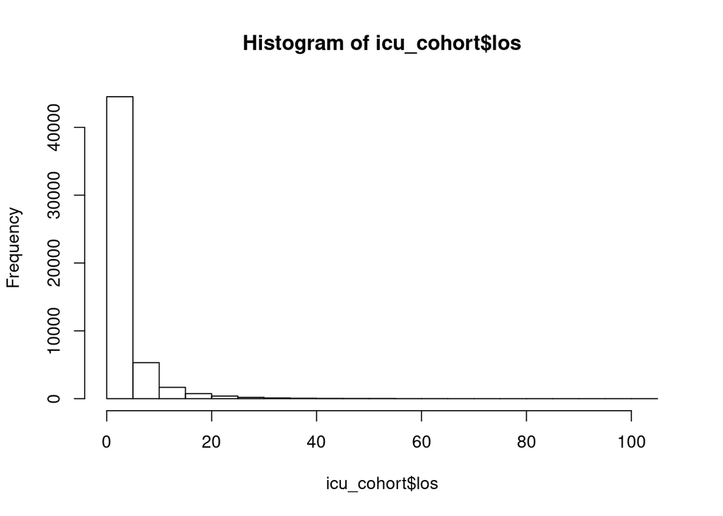

```r
hist(icu_cohort$los)
```

```r
tail(sort(icu_cohort$los),100)
```

```
##   [1]  41.01611  41.23115  41.26624  41.34685  41.47310  41.47647  41.56701
##   [8]  41.61632  41.70623  42.49509  42.64980  42.65020  42.69895  42.77602
##  [15]  43.00344  43.02359  43.05031  43.05457  43.08742  43.22860  43.35451
##  [22]  43.39657  44.02627  44.17606  44.25787  44.39138  44.82361  44.95395
##  [29]  45.10642  45.12696  45.21032  45.21059  45.27223  45.34098  45.37499
##  [36]  46.13321  46.28455  46.43918  46.91218  46.98587  47.02951  47.05014
##  [43]  47.20697  48.53829  48.89186  48.92458  49.12062  49.78659  49.90523
##  [50]  50.05191  50.15788  50.17666  50.26021  50.55223  50.86005  51.20484
##  [57]  51.35404  51.43669  51.66047  51.80905  51.80978  52.06345  52.20663
##  [64]  52.22512  52.53012  52.81076  53.06152  53.44668  53.48425  53.88369
##  [71]  54.29663  54.54574  54.87676  55.04108  55.72022  55.99675  57.91227
##  [78]  58.09610  59.03738  59.46730  59.63462  60.85733  60.87995  60.99439
##  [85]  61.02127  61.87389  61.92626  63.40932  63.57603  63.85269  66.26734
##  [92]  66.58424  67.87067  69.80475  74.30507  77.74071  79.04821  95.83822
##  [99]  99.63845 103.49900
```

```r
# 2) labvaluenum - values lager than 200 cmay be thought as error (Outlier?)
summary(icu_cohort$labvaluenum)
```

```
##    Min. 1st Qu.  Median    Mean 3rd Qu.    Max.
##    0.10   24.00   30.20   34.18   39.40  449.00
```

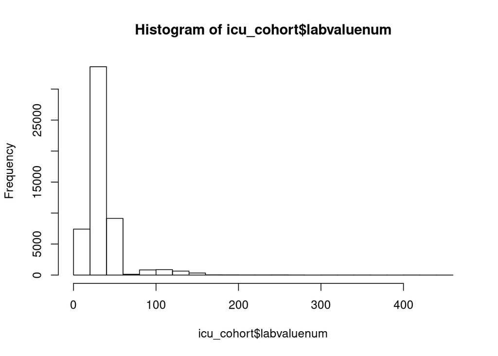

```r
hist(icu_cohort$labvaluenum)
```

```r
tail(sort(icu_cohort$labvaluenum),100)
```

```
##   [1] 185 186 186 187 188 189 192 193 193 194 194 194 194 194 195 196 198 201
##  [19] 201 201 204 204 204 204 205 206 207 208 216 217 221 223 224 225 225 229
##  [37] 230 233 233 234 236 236 237 242 245 245 247 248 248 248 250 250 251 251
##  [55] 255 258 258 259 259 261 262 263 265 268 270 270 270 273 279 280 284 285
##  [73] 291 303 308 313 313 317 318 322 327 338 340 343 344 345 355 361 365 365
##  [91] 393 397 404 414 414 416 431 438 447 449
```

```r
# 3) vitalvalunum - the value of 3333330 must be wrong
summary(icu_cohort$vitalvaluenum)
```

```
##    Min. 1st Qu.  Median    Mean 3rd Qu.    Max.
##       0      76      91     153     101 3333330
```

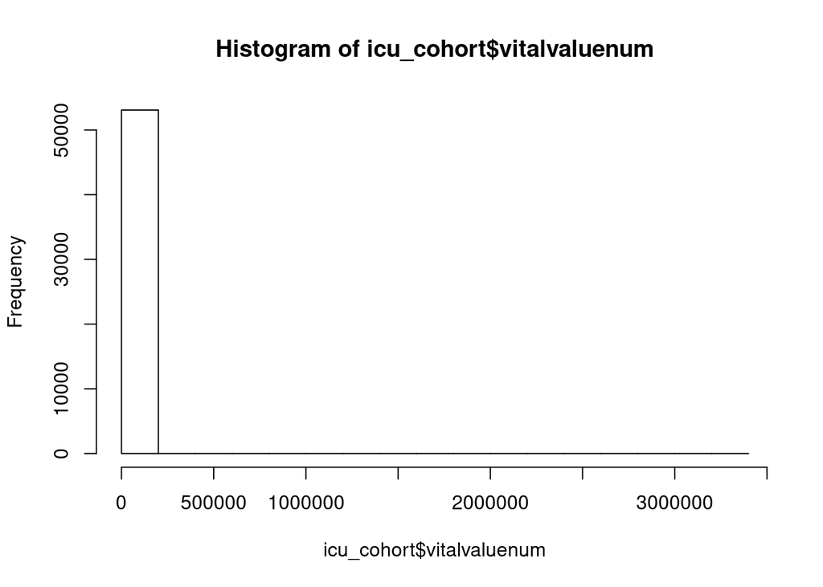

```r
hist(icu_cohort$vitalvaluenum)
```

```r
tail(sort(icu_cohort$vitalvaluenum),100)
```

```
##   [1]     187     187     188     188     188     188     188     188     188
##  [10]     188     188     188     189     189     189     189     189     189
##  [19]     190     190     190     190     190     190     190     191     191
##  [28]     191     192     192     192     192     193     193     193     193
##  [37]     193     193     193     194     194     194     194     194     194
##  [46]     194     194     195     195     195     195     195     196     196
##  [55]     196     196     196     197     198     198     198     198     199
##  [64]     199     199     200     200     200     200     202     202     202
##  [73]     205     206     206     206     206     207     207     208     209
##  [82]     209     209     210     212     212     213     219     220     222
##  [91]     222     223     224     225     228     244     253     756     941
## [100] 3333330
```

```r
# 4) length-values lager than 100 may be thought as error inputs (or Outlier?)
summary(icu_cohort$length)
```

```
##    Min. 1st Qu.  Median    Mean 3rd Qu.    Max.
##   0.000   0.000   0.000   1.186   0.000 378.000
```

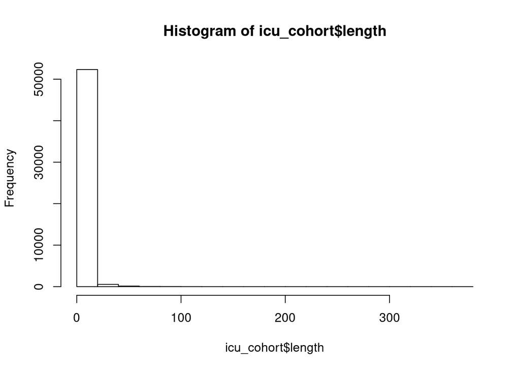

```r
hist(icu_cohort$length)
```

```r
tail(sort(icu_cohort$length),100)
```

```
##   [1]  54  54  54  54  54  55  55  55  56  56  56  57  57  57  57  57  57  58
##  [19]  58  58  59  59  59  61  61  61  61  62  62  62  62  64  65  66  66  67
##  [37]  67  68  68  69  70  71  72  72  72  72  73  73  74  75  76  76  78  78
##  [55]  78  79  79  80  80  82  82  82  83  84  84  86  86  86  87  87  88  88
##  [73]  88  91  94  95  96  97  98  98  99 100 106 106 107 107 108 110 116 120
##  [91] 123 131 146 165 177 207 211 249 375 378
```

```r
table(icu_cohort$ethnicity)
```

```
##
## AMERICAN INDIAN/ALASKA NATIVE                         ASIAN
##                            94                          1571
##        BLACK/AFRICAN AMERICAN               HISPANIC/LATINO
##                          4873                          1833
##                         OTHER              UNABLE TO OBTAIN
##                          2523                           733
##                       UNKNOWN                         WHITE
##                          5727                         35733
```

Replace these errors or outliers with N/A

```r
icu_cohort$los[icu_cohort$los > 40]  <- NA
icu_cohort$labvaluenum[icu_cohort$labvaluenum > 200]  <- NA
icu_cohort$vitalvaluenum[icu_cohort$vitalvaluenum>1000]  <- NA
icu_cohort$length[icu_cohort$length>100]  <- NA
```

Check the missing info for the upadted table

```r
na_count2 <- sapply(icu_cohort, function(x) sum(is.na(x)))

na_count2 <- data.frame(na_count2)
na_count2
```

```
##                      na_count2
## subject_id                   0
## hadm_id                      0
## stay_id                      0
## first_careunit               0
## last_careunit                0
## intime                       0
## outtime                      0
## los                        106
## admittime                    0
## dischtime                    0
## admission_type               0
## admission_location           0
## discharge_location         506
## insurance                    0
## language                     0
## marital_status            4561
## ethnicity                    0
## hospital_expire_flag         0
## Year                         0
## Month                        0
## monthday                     0
## weekday                      0
## hour                         0
## gender                       0
## anchor_age                   0
## anchor_year                  0
## anchor_year_group            0
## labitemid                    0
## labvaluenum                 83
## vitalitemid                  0
## vitalvaluenum                1
## length                      18
## thirty_day_mort              0
```

### 4. Impute missing values by `miceRanger` (request $m=3$ data sets). This step is computational intensive. Make sure to save the imputation results as a file. Hint: Setting `max.depth=10` in the `miceRanger` function may cut some computing time.

```r
#miceObj <- miceRanger(
#     icu_cohort
#    , m=3
#    , returnModels = TRUE
#    , verbose = FALSE
#    , max.depth = 10
#    , max.depth = 10
#  )
# write_rds(miceObj, file = "miceObj.rds"

miceObj <- read_rds("~/Biostat-203b-winter-2022/HW4/miceObj.rds")
class(miceObj)
```

```
## [1] "miceDefs"
```

Save the imputation results as a file

```r
#imputed_data1 = dataList$Dataset_1
#imputed_data2 = dataList$Dataset_2
#imputed_data3 = dataList$Dataset_3
#save(imputed_data1, imputed_data2, imputed_data3, file = "imputed_data.rds")
```

```r
#dataList <- completeData(miceObj)
#imputed_data1 = dataList$Dataset_1
#imputed_data2 = dataList$Dataset_2
#imputed_data3 = dataList$Dataset_3
#save(imputed_data1, imputed_data2, imputed_data3, file = "imputed_data.RData")
```

```r
#na_count3 <-sapply(imputed_data1, function(x) sum(is.na(x)))
#na_count3 <- data.frame(na_count3)
#na_count3
```

### 5. Make imputation diagnostic plots and explain what they mean.

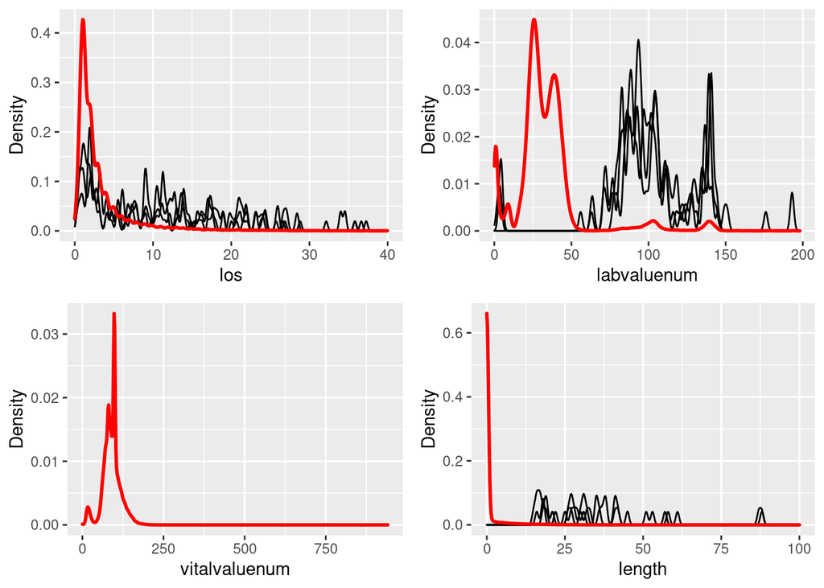

```r
plotDistributions(miceObj ,vars='allNumeric')
```

2. Convergence of Correlation The plots show box-plots of the correlations between the imputed values in every combination of datasets, at each iteration. It seemed our values between datasets didn’t converge very well over the first five iterations

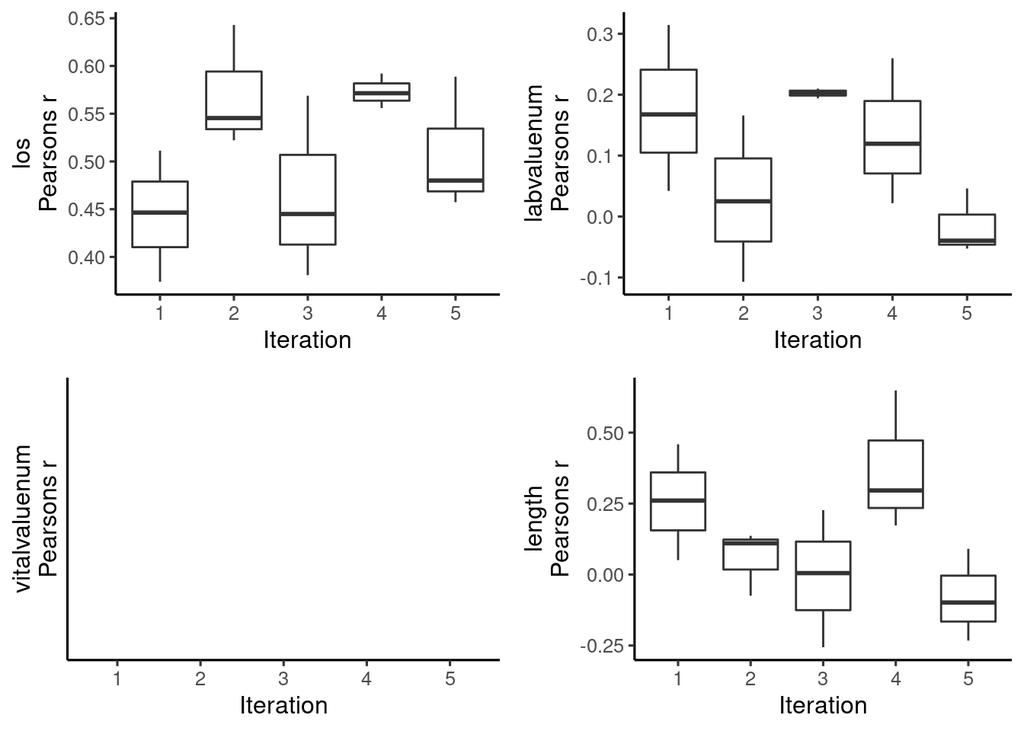

```r
plotCorrelations(miceObj,vars = 'allNumeric')
```

3. Center and Dispersion Convergence It seemed the imputed data didn’t converge very well and we may need to run more iterations.

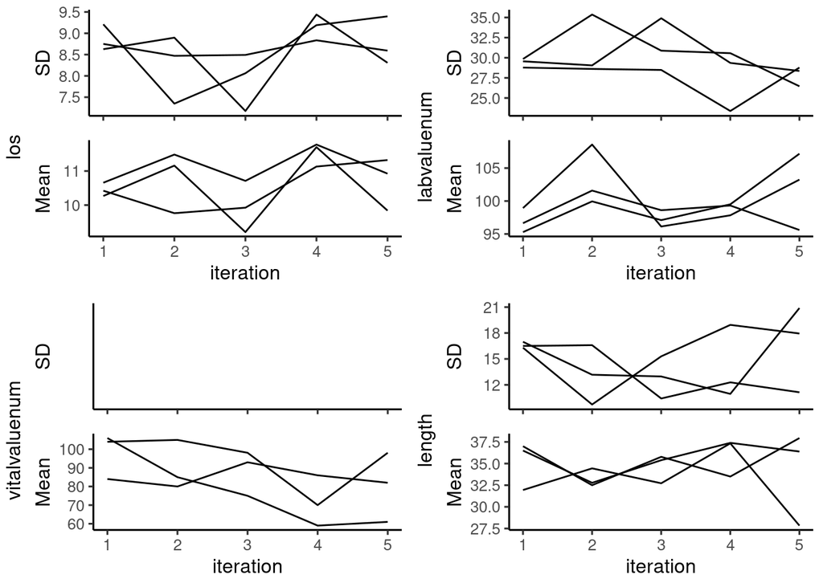

```r
plotVarConvergence(miceObj,vars = 'allNumeric')
```

4. Model OOB Error “Random Forests give us a cheap way to determine model error without cross validation. Each model returns the OOB accuracy for classification, and r-squared for regression. We can see how these converged as the iterations progress.”

It looked like the variables were not imputed with a reasonable degree of accuracy

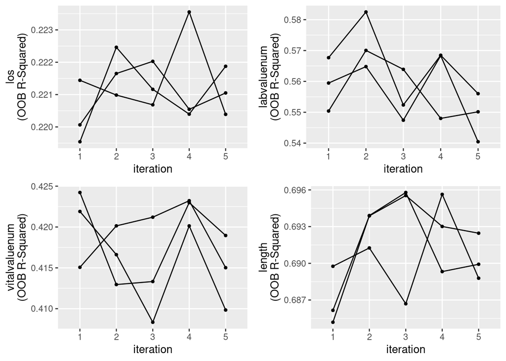

```r
plotModelError(miceObj,vars = 'allNumeric')
```

5. Variable Importance The plots showed the variable importance for each imputed variable.

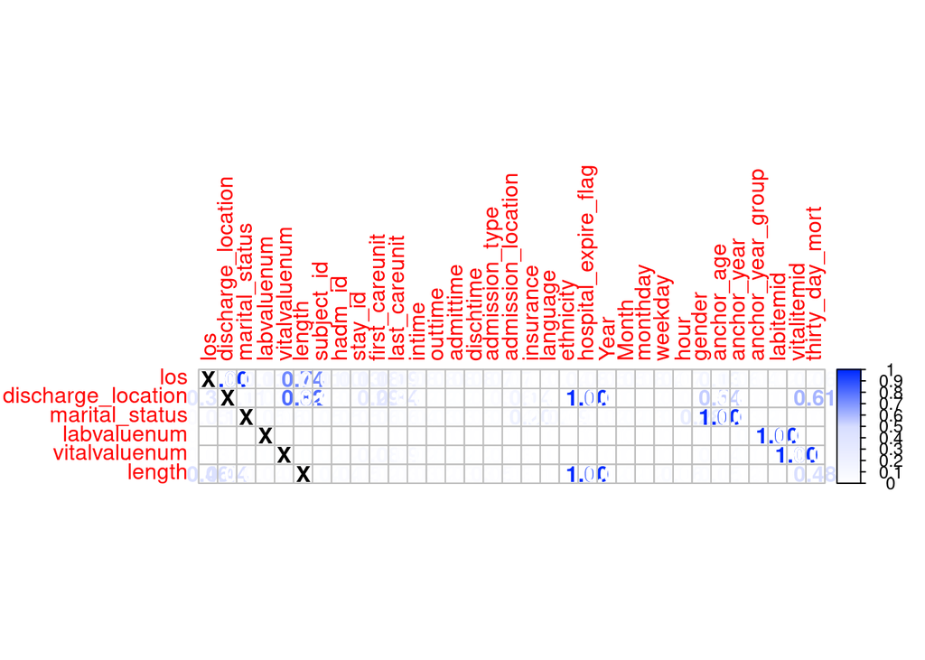

```r
plotVarImportance(miceObj)
```

### 6. Choose one of the imputed data sets to be used in Q2. This is **not** a good idea to use just one imputed data set or to average multiple imputed data sets. Explain in a couple of sentences what the correct Multiple Imputation strategy is.

**Solutions:** I chose the first data set to be used in Q2.

reference: https://stats.oarc.ucla.edu/sas/seminars/multiple-imputation-in-sas/mi_new_1/

The results obtained from the imputed data sets must be pooled in order to obtain a set of final parameter estimates and inferences. So a proper strategy is to obtain the ideally final parameter estimates by combining the parameter estimates obtained from each analysis which may use different models.

“MI” has three basic phases:

1. Imputation or Fill-in Phase: The missing data are filled in with estimated values and a complete data set is created. This process of fill-in is repeated m times.
2. Analysis Phase: Each of the m complete data sets is then analyzed using a statistical method of interest (e.g. linear regression).
3. Pooling Phase: The parameter estimates (e.g. coefficients and standard errors) obtained from each analyzed data set are then combined for inference.”

## Q2. Predicting 30-day mortality

Develop at least two analytic approaches for predicting the 30-day mortality of patients admitted to ICU using demographic information (gender, age, marital status, ethnicity), first lab measurements during ICU stay, and first vital measurements during ICU stay. For example, you can use (1) logistic regression (`glm()` function in base R or keras), (2) logistic regression with lasso penalty (glmnet or keras package), (3) random forest (randomForest package), or (4) neural network (keras package).

### 1. Partition data into 80% training set and 20% test set. Stratify partitioning according the 30-day mortality status.

```r
 load("~/Biostat-203b-winter-2022/HW4/imputed_data1.RData")
#stratify the data into two groups according to the binary variable

set.seed(123)
imputed_data1 <- imputed_data1 %>%
  mutate(age = anchor_age + year(admittime) - anchor_year)
thiry_day_mortality_status0 <- imputed_data1[imputed_data1$thirty_day_mort == 0]
thiry_day_mortality_status1 <- imputed_data1[imputed_data1$thirty_day_mort == 1]
dim(thiry_day_mortality_status0)
```

```
## [1] 47600    34
```

```r
dim(thiry_day_mortality_status1)
```

```
## [1] 5487   34
```

```r
## for thiry_day_mortality_status = 0
# Get the number of observations
n_obs0 <- nrow(thiry_day_mortality_status0)
# Shuffle row indices: permuted_rows
permuted_rows0 <- sample(n_obs0)
# Randomly order data
my_data0 <- thiry_day_mortality_status0[permuted_rows0, ]
# Identify row to split on: split
split0 <- n_obs0 *0.8
# Training set + Test set
train_data0 <- thiry_day_mortality_status0[ 1:split0, ]
test_data0 <- thiry_day_mortality_status0[(split0+1):n_obs0, ]
dim(thiry_day_mortality_status0)
```

```
## [1] 47600    34
```

```r
dim(train_data0)
```

```
## [1] 38080    34
```

```r
dim(test_data0)
```

```
## [1] 9520   34
```

```r
## for thiry_day_mortality_status = 1
# Get the number of observations
n_obs1 <- nrow(thiry_day_mortality_status1)
# Shuffle row indices: permuted_rows
permuted_rows1 <- sample(n_obs1)
# Randomly order data
my_data1 <- thiry_day_mortality_status1[permuted_rows1, ]
# Identify row to split on: split
split1 <- round(n_obs1 *0.8)
# Training set + Test set
train_data1 <- thiry_day_mortality_status1[ 1:split1, ]
test_data1 <- thiry_day_mortality_status1[(split1+1):(n_obs1), ]
dim(thiry_day_mortality_status1)
```

```
## [1] 5487   34
```

```r
dim(train_data1)
```

```
## [1] 4390   34
```

```r
dim(test_data1)
```

```
## [1] 1097   34
```

```r
# Assmble the training and testing sets
training_set <- rbind(train_data0, train_data1)
dim(training_set)
```

```
## [1] 42470    34
```

```r
testing_set <- rbind(test_data0, test_data1)
dim(testing_set)
```

```
## [1] 10617    34
```

```r
dim(icu_cohort)
```

```
## [1] 53087    33
```

### 2. Train the 2 models using the training set.

#### Model 1: GLM (thirty_day_mort ~ gender + age+ ethnicity + marital_status + labvaluenum + as.factor(labitemid) + vitalvaluenum) + as.factor(vitalitemid)

```r
training_set$gender <- as.factor(training_set$gender)
training_set$ethnicity  <- as.factor(training_set$ethnicity )
training_set$marital_status  <- as.factor(training_set$marital_status)
training_set$labitemid <- as.factor(training_set$labitemid)
training_set$vitalitemid <- as.factor(training_set$vitalitemid)


model1 <- glm(as.factor(thirty_day_mort) ~ gender + age+ ethnicity + marital_status +
                   labitemid + vitalitemid + labvaluenum +vitalvaluenum,
             data = training_set,
             family = 'binomial')

summary(model1)
```

```
##
## Call:
## glm(formula = as.factor(thirty_day_mort) ~ gender + age + ethnicity +
##     marital_status + labitemid + vitalitemid + labvaluenum +
##     vitalvaluenum, family = "binomial", data = training_set)
##
## Deviance Residuals:
##     Min       1Q   Median       3Q      Max
## -3.9651  -0.5062  -0.4079  -0.3201   2.9741
##
## Coefficients:
##                                   Estimate Std. Error z value Pr(>|z|)
## (Intercept)                     -5.5505728  0.5399556 -10.280  < 2e-16 ***
## genderM                         -0.0063879  0.0343494  -0.186 0.852470
## age                              0.0314015  0.0011884  26.424  < 2e-16 ***
## ethnicityASIAN                   0.7799007  0.5271748   1.479 0.139034
## ethnicityBLACK/AFRICAN AMERICAN  0.5196950  0.5223444   0.995 0.319771
## ethnicityHISPANIC/LATINO         0.5340283  0.5285692   1.010 0.312338
## ethnicityOTHER                   0.5066116  0.5255377   0.964 0.335052
## ethnicityUNABLE TO OBTAIN        1.1904969  0.5315469   2.240 0.025111 *
## ethnicityUNKNOWN                 1.3217859  0.5207345   2.538 0.011139 *
## ethnicityWHITE                   0.4999320  0.5195913   0.962 0.335967
## marital_statusMARRIED           -0.0099098  0.0654282  -0.151 0.879613
## marital_statusSINGLE             0.1108182  0.0692592   1.600 0.109587
## marital_statusWIDOWED            0.0377582  0.0735094   0.514 0.607496
## labitemid50893                   0.2352780  0.1138579   2.066 0.038789 *
## labitemid50902                   1.7552128  0.2546292   6.893 5.45e-12 ***
## labitemid50912                  -0.2169426  0.0999995  -2.169 0.030050 *
## labitemid50931                   1.6288257  0.2372999   6.864 6.70e-12 ***
## labitemid50960                  -0.5467801  0.4801474  -1.139 0.254797
## labitemid50971                  -0.6069962  0.2884784  -2.104 0.035367 *
## labitemid50983                   2.4738277  0.3631372   6.812 9.60e-12 ***
## labitemid51221                   0.3244078  0.0512725   6.327 2.50e-10 ***
## labitemid51301                   0.2018232  0.1345934   1.500 0.133743
## vitalitemid220179               -0.2414016  0.0623255  -3.873 0.000107 ***
## vitalitemid220181                0.1504625  0.2211401   0.680 0.496255
## vitalitemid220210                0.7172597  0.0959274   7.477 7.60e-14 ***
## vitalitemid223761               -0.1401824  0.0487419  -2.876 0.004027 **
## labvaluenum                     -0.0204586  0.0029687  -6.891 5.52e-12 ***
## vitalvaluenum                    0.0114139  0.0008289  13.770  < 2e-16 ***
## ---
## Signif. codes:  0 '***' 0.001 '**' 0.01 '*' 0.05 '.' 0.1 ' ' 1
##
## (Dispersion parameter for binomial family taken to be 1)
##
##     Null deviance: 28236  on 42469  degrees of freedom
## Residual deviance: 26749  on 42442  degrees of freedom
## AIC: 26805
##
## Number of Fisher Scoring iterations: 5
```

#### Model 2: Fit the lasso penalized logistic regression model:

```r
library(glmnet)
set.seed(345)
modeldata <-  training_set %>%
  select(thirty_day_mort, gender, age, ethnicity, marital_status,
                   labitemid, labvaluenum, vitalitemid, vitalvaluenum)

# Dummy code categorical predictor variables
x <- model.matrix(thirty_day_mort ~. , modeldata)[,-1]
y <- modeldata$thirty_day_mort

# Find the best lambda using cross-validation
set.seed(123)
cv.lasso <- cv.glmnet(x, y, alpha = 1, family = "binomial")


# Fit the final model on the training data
model2 <- glmnet(x, y, alpha = 1, family = "binomial",
                lambda = cv.lasso$lambda.min)

# Display regression coefficients
coef(model1)
```

```
##                     (Intercept)                         genderM
##                    -5.550572840                    -0.006387871
##                             age                  ethnicityASIAN
##                     0.031401505                     0.779900657
## ethnicityBLACK/AFRICAN AMERICAN        ethnicityHISPANIC/LATINO
##                     0.519694997                     0.534028283
##                  ethnicityOTHER       ethnicityUNABLE TO OBTAIN
##                     0.506611597                     1.190496923
##                ethnicityUNKNOWN                  ethnicityWHITE
##                     1.321785865                     0.499932027
##           marital_statusMARRIED            marital_statusSINGLE
##                    -0.009909761                     0.110818210
##           marital_statusWIDOWED                  labitemid50893
##                     0.037758158                     0.235278037
##                  labitemid50902                  labitemid50912
##                     1.755212803                    -0.216942581
##                  labitemid50931                  labitemid50960
##                     1.628825723                    -0.546780066
##                  labitemid50971                  labitemid50983
##                    -0.606996192                     2.473827749
##                  labitemid51221                  labitemid51301
##                     0.324407814                     0.201823168
##               vitalitemid220179               vitalitemid220181
##                    -0.241401611                     0.150462455
##               vitalitemid220210               vitalitemid223761
##                     0.717259686                    -0.140182398
##                     labvaluenum                   vitalvaluenum
##                    -0.020458593                     0.011413871
```

```r
coef(model2)
```

```
## 28 x 1 sparse Matrix of class "dgCMatrix"
##                                           s0
## (Intercept)                     -5.090876362
## genderM                         -0.008129285
## age                              0.031296038
## ethnicityASIAN                   0.262264625
## ethnicityBLACK/AFRICAN AMERICAN  0.006697983
## ethnicityHISPANIC/LATINO         0.015103868
## ethnicityOTHER                   .
## ethnicityUNABLE TO OBTAIN        0.675312438
## ethnicityUNKNOWN                 0.811862734
## ethnicityWHITE                  -0.008913479
## marital_statusMARRIED           -0.012964909
## marital_statusSINGLE             0.104703098
## marital_statusWIDOWED            0.033214888
## labitemid50893                   0.278294322
## labitemid50902                   1.495783075
## labitemid50912                  -0.138127798
## labitemid50931                   1.388312848
## labitemid50960                  -0.436899447
## labitemid50971                  -0.517803434
## labitemid50983                   2.088289314
## labitemid51221                   0.280052050
## labitemid51301                   0.239539172
## labvaluenum                     -0.017227757
## vitalitemid220179               -0.229721172
## vitalitemid220181                0.137236290
## vitalitemid220210                0.700218663
## vitalitemid223761               -0.134388210
## vitalvaluenum                    0.011235442
```

### 3. Compare model prediction performance on the test set.

#### Model 1:

Error rate: 0.121

Specificity: 0.569 (cut-off = 0.095)

Sensitivity: 0.709 (cut-off = 0.095)

The plot shows at a threshold of 0.095, the corresponding sensitivity and specificity are 70.9% and 57% respectively, which means the model has a just so-so performance. In addition, the error rate would be pretty high at this cut-off. So I adjusted the cut-off to 0.23 when using the fitted model to predict for the testing data set.

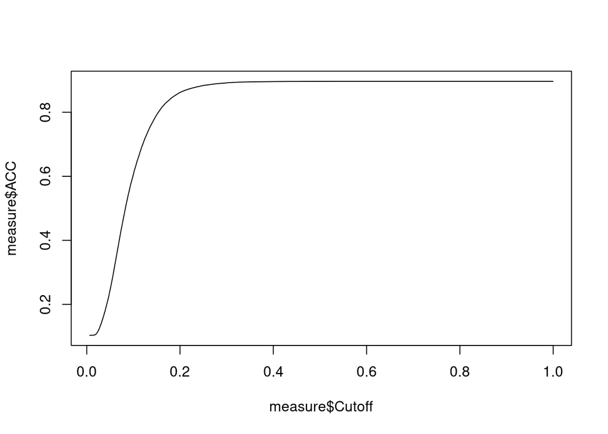

```r
# Make predictions on the test data
testing_set$gender <- as.factor(testing_set$gender)
testing_set$ethnicity  <- as.factor(testing_set$ethnicity )
testing_set$marital_status  <- as.factor(testing_set$marital_status)
testing_set$labitemid <- as.factor(testing_set$labitemid)
testing_set$vitalitemid <- as.factor(testing_set$vitalitemid)
new_x <-  testing_set %>%
  select(thirty_day_mort, gender, age, ethnicity, marital_status,
         labitemid, labvaluenum, vitalitemid, vitalvaluenum)


# Performance metrics of binary classifier  -- find the cutoff = 0.23
library(ROCit)
measure <- measureit(score = model1$fitted.values, class =model1$y ,
                     measure = c("ACC", "MIS", "SENS", "SPEC"))
plot(measure$ACC~measure$Cutoff, type = "l")
```

```r
# After finding the cutoff, use it
possibility <- predict(model1, newdata = new_x,  type="response") # predicted values
predicted <- ifelse(possibility > 0.23, 1, 0) #cutoff = 0.23


# Model accuracy,
# accuracy
observed <- testing_set$thirty_day_mort
mean(predicted == observed)
```

```
## [1] 0.8793444
```

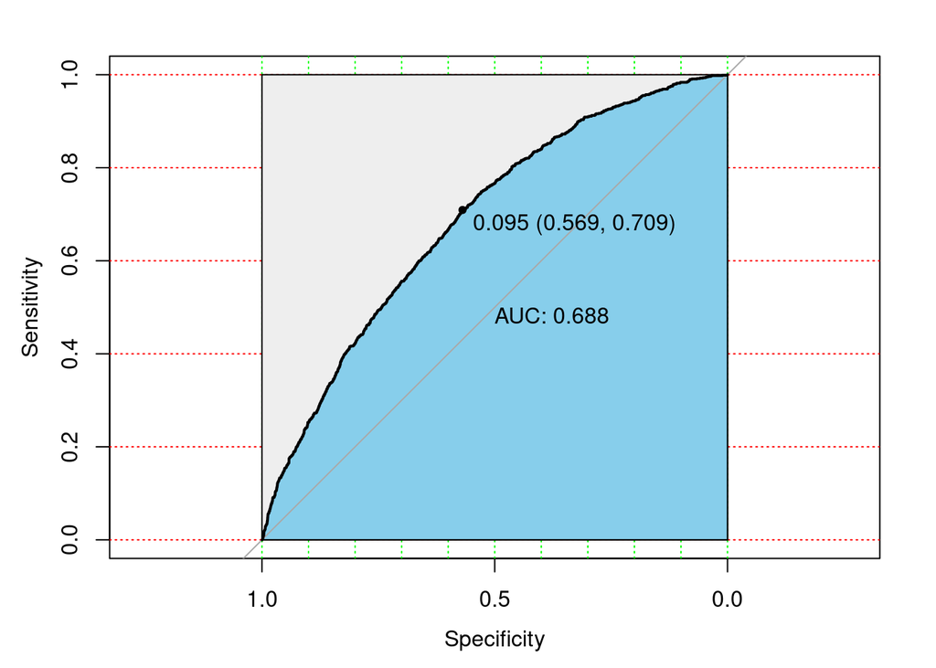

```r
# ROC Curve, specificity, sensitivity
library(pROC)
modelroc <- roc(observed,possibility)
plot(modelroc, print.auc=TRUE, auc.polygon=TRUE, grid=c(0.1, 0.2),
     grid.col=c("green", "red"), max.auc.polygon=TRUE,
     auc.polygon.col="skyblue", print.thres=TRUE)
```

#### Model 2:

Error rate: 0.120

Specificity: 0.537 (cut-off = 0.091)

The plot shows at a threshold of 0.091, the corresponding sensitivity and specificity are 74% and 54% respectively, which means the model has a just so-so performance. In addition, the error rate would be pretty high at this cut-off. So I adjusted the cut-off to 0.23 when using the fitted model to predict for the testing data set. The final predictive accuracy is 88%.

```r
library(glmnet)
set.seed(345)
modeldata <-  training_set %>%
  select(thirty_day_mort, gender, age, ethnicity, marital_status,
                   labitemid, labvaluenum, vitalitemid, vitalvaluenum)

# Dummy code categorical predictor variables
x <- model.matrix(thirty_day_mort ~. , modeldata)[,-1]
y <- modeldata$thirty_day_mort

# Find the best lambda using cross-validation
set.seed(123)
cv.lasso <- cv.glmnet(x, y, alpha = 1, family = "binomial")


# Fit the final model on the training data
model2 <- glmnet(x, y, alpha = 1, family = "binomial",
                lambda = cv.lasso$lambda.min)

# Display regression coefficients
coef(model1)
```

```
##                     (Intercept)                         genderM
##                    -5.550572840                    -0.006387871
##                             age                  ethnicityASIAN
##                     0.031401505                     0.779900657
## ethnicityBLACK/AFRICAN AMERICAN        ethnicityHISPANIC/LATINO
##                     0.519694997                     0.534028283
##                  ethnicityOTHER       ethnicityUNABLE TO OBTAIN
##                     0.506611597                     1.190496923
##                ethnicityUNKNOWN                  ethnicityWHITE
##                     1.321785865                     0.499932027
##           marital_statusMARRIED            marital_statusSINGLE
##                    -0.009909761                     0.110818210
##           marital_statusWIDOWED                  labitemid50893
##                     0.037758158                     0.235278037
##                  labitemid50902                  labitemid50912
##                     1.755212803                    -0.216942581
##                  labitemid50931                  labitemid50960
##                     1.628825723                    -0.546780066
##                  labitemid50971                  labitemid50983
##                    -0.606996192                     2.473827749
##                  labitemid51221                  labitemid51301
##                     0.324407814                     0.201823168
##               vitalitemid220179               vitalitemid220181
##                    -0.241401611                     0.150462455
##               vitalitemid220210               vitalitemid223761
##                     0.717259686                    -0.140182398
##                     labvaluenum                   vitalvaluenum
##                    -0.020458593                     0.011413871
```

```r
coef(model2)
```

```
## 28 x 1 sparse Matrix of class "dgCMatrix"
##                                           s0
## (Intercept)                     -5.090876362
## genderM                         -0.008129285
## age                              0.031296038
## ethnicityASIAN                   0.262264625
## ethnicityBLACK/AFRICAN AMERICAN  0.006697983
## ethnicityHISPANIC/LATINO         0.015103868
## ethnicityOTHER                   .
## ethnicityUNABLE TO OBTAIN        0.675312438
## ethnicityUNKNOWN                 0.811862734
## ethnicityWHITE                  -0.008913479
## marital_statusMARRIED           -0.012964909
## marital_statusSINGLE             0.104703098
## marital_statusWIDOWED            0.033214888
## labitemid50893                   0.278294322
## labitemid50902                   1.495783075
## labitemid50912                  -0.138127798
## labitemid50931                   1.388312848
## labitemid50960                  -0.436899447
## labitemid50971                  -0.517803434
## labitemid50983                   2.088289314
## labitemid51221                   0.280052050
## labitemid51301                   0.239539172
## labvaluenum                     -0.017227757
## vitalitemid220179               -0.229721172
## vitalitemid220181                0.137236290
## vitalitemid220210                0.700218663
## vitalitemid223761               -0.134388210
## vitalvaluenum                    0.011235442
```

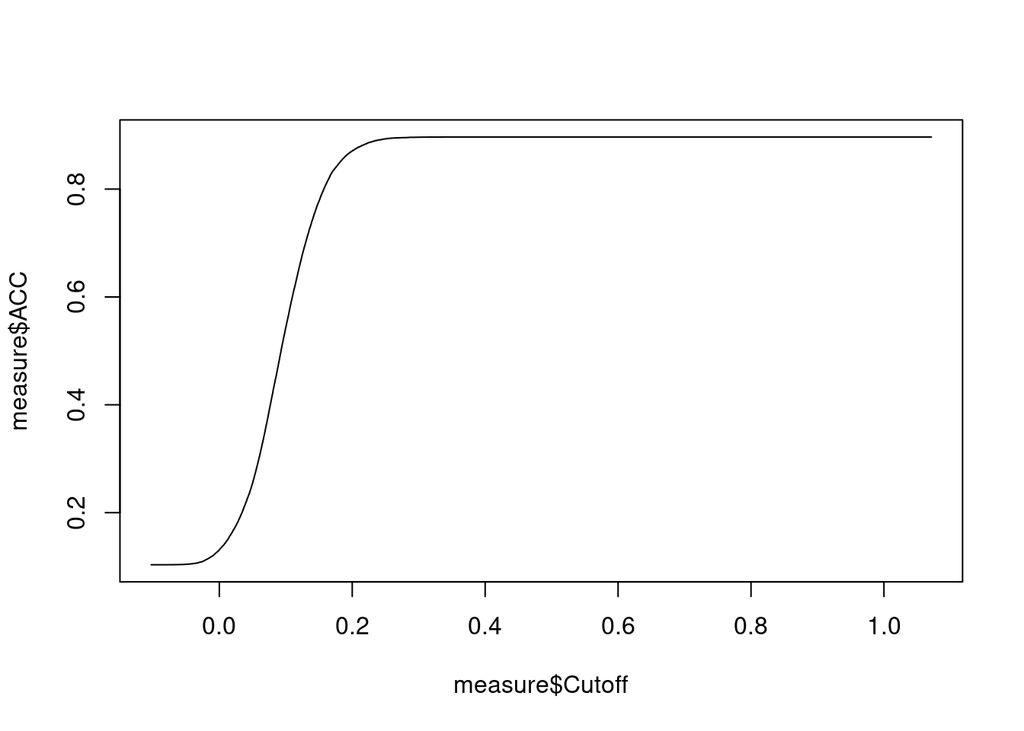

```r
# Make predictions on the test data
modeldata2 <-  testing_set %>%
  select(thirty_day_mort, gender, age, ethnicity, marital_status,
          labitemid, labvaluenum, vitalitemid, vitalvaluenum)

# Dummy code categorical predictor variables
x2 <- model.matrix(thirty_day_mort ~. , modeldata2)[,-1]
y2 <- modeldata2$thirty_day_mort

#x.test <- model.matrix(thirty_day_mort ~. , modeldata2)[,-1]


# Performance metrics of binary classifier  -- find the cut-off is 0.23
fitted_value <-as.vector(predict( glmnet(x,y),newx=x, s=cv.lasso$lambda.min ))
y2 <- modeldata2$thirty_day_mort

measure <- measureit(score = fitted_value, class = y ,
                     measure = c("ACC", "MIS", "SENS", "SPEC"))
plot(measure$ACC~measure$Cutoff, type = "l")
```

```r
# After finding the cutoff, use it
probabilities <- model2 %>% predict(newx = x2, type = 'response') #predicted values
predicted_classes <- as.vector(ifelse(probabilities > 0.23, 1, 0)) #cutoff = 0.23
# Model accuracy
observed_classes <- modeldata2$thirty_day_mort
mean(predicted_classes == observed_classes)
```

```
## [1] 0.8799096
```

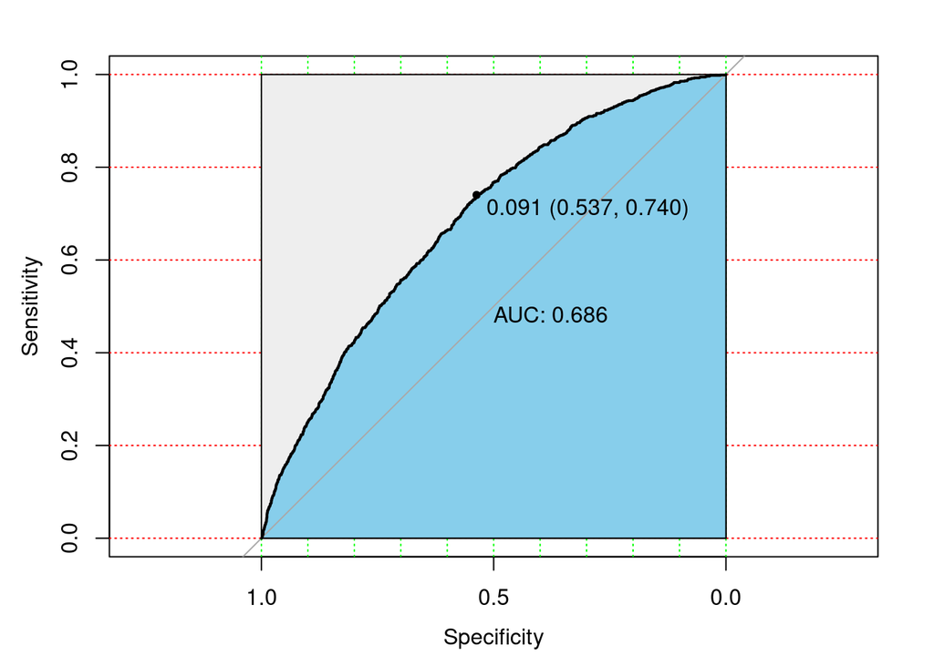

```r
# ROC Curve, specificity, sensitivity
library(pROC)
modelroc <- roc(observed_classes,probabilities)
plot(modelroc, print.auc=TRUE, auc.polygon=TRUE, grid=c(0.1, 0.2),
     grid.col=c("green", "red"), max.auc.polygon=TRUE,
     auc.polygon.col="skyblue", print.thres=TRUE)
```

In conclusion, the two models have about the same good performance in predictions.